# Twitter Analysis about new Omicron Variant

### Question 5: What is the correlation of the number of Twitter followers and the number of retweets for each Omicron user topic?

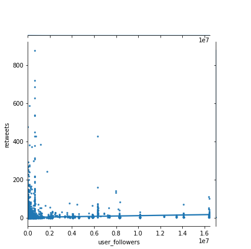

```python
# We may need a bigger plot size to clearly show the relationship

### BEGIN SOLUTION
plt.figure(figsize=(13, 8))
sns.jointplot(x = "user_followers", y = "retweets",
              kind = "reg", data = omicron, scatter_kws={"s": 5})

### END SOLUTION
```

What trend do you observe regarding the correlation of user popularity and the sharing of Omicron posts described by Twitter retweets? What could you infer from the graph?

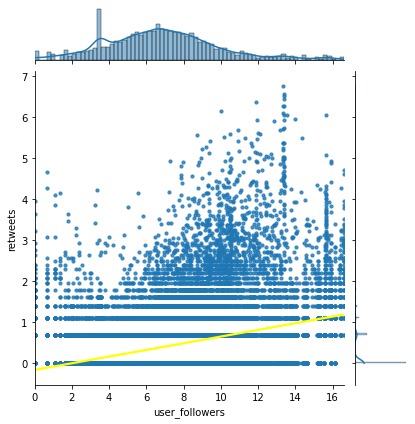

```python
# What about changing both the user_followers and retweets into logarithmic scale? Does it look different?

plt.figure(figsize=(13, 8))
sns.jointplot(x = np.log(omicron["user_followers"] + 1), y = np.log(omicron["retweets"] +1),
              kind = "reg", scatter_kws={"s": 10}, joint_kws={'line_kws':{'color':'yellow'}})
```

Interpret your observations.

### Question 6: Draw a heatmap. What does the correlation between variables tell you about Omicron?

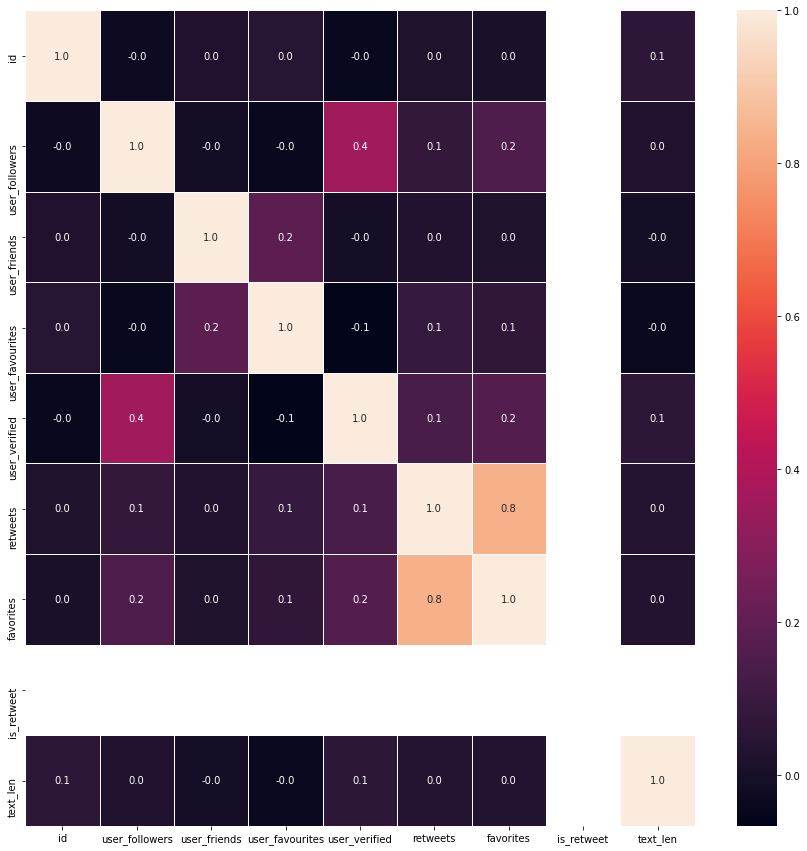

```python
### BEGIN SOLUTION
f, ax = plt.subplots(figsize=(15, 15))
sns.heatmap(omicron.corr(), annot = True,
           linewidth = .6, fmt='.1f', ax = ax)
### END SOLUTION
```

What major associations do you observe in the heatmap?

Congratulations! You have reached the end of the project. Finally, what are 1-2 research questions that you think relevant to Omicron and the dataset we have?